# 11월18일2

238STG02 이민주

2023-11-18

```r
setwd("~/Desktop/2023-2/이론통계학II/HW9")
dat <- read_excel("Framingham.xls",
                  col_types = c("numeric", "numeric", "numeric", "numeric", "numeric", "numeric", "numeric", "numeric", "skip", "numeric","numeric")) %>%
  mutate(sex=as.factor(sex), month=as.factor(month), chdfate=as.factor(chdfate))
```

**NA는 KNN imputation**

k=10 (default)

```r
## imputation 용 dat의 복사본
dat_temp<-dat %>% dplyr::select(sbp, dbp, scl, age, bmi, sex, month)
aaa <- dat_temp[complete.cases(dat_temp)!=TRUE,]$id
#for(i in 1:length(aaa)){
#  temp1<-rbind(dat_temp[aaa[i],],dat_temp[-aaa,])
#  dat_temp[aaa[i],]<-myimputation(temp1)[1,]
#}
anyNA(dat_temp)
dat_temp<-myimputation(dat_temp)
#dat_temp[aaa,]
## 원래 거에 다시 붙이기
dat_KNN<-dat
dat_KNN[aaa,]
dat_KNN[aaa,c("scl","bmi")]<-dat_temp[aaa,c("scl","bmi")]
dat_KNN[aaa,]
anyNA(dat_KNN)
```

**Outlier 73개 제거**

dat_KNN_noOUT

```r
myOUT<-detect_outliers(dat_KNN, n=1, features = c("sbp","dbp","scl","age","bmi"));myOUT
```

```
##  [1]   46  166  213  352  380  548  606  614  659  738  978 1046 1056 1100 1195
## [16] 1225 1233 1327 1347 1441 1442 1449 1530 1654 1789 1871 1939 2049 2098 2166
## [31] 2191 2236 2280 2337 2348 2383 2387 2533 2550 2603 2641 2649 2710 2772 2784
## [46] 2808 2857 2918 2972 3009 3079 3208 3307 3391 3493 3515 3526 3539 3569 3687
## [61] 3779 3823 3863 3898 3946 4075 4095 4174 4216 4229 4559 4606 4622
```

```r
dat_KNN_noOUT <- dat_KNN[-myOUT,]
```

**파생변수 처리**

dat_FIN

```r
dat_FIN<-dat_KNN_noOUT %>%
  mutate(scl=log(scl/mean(scl)),
         month=as.factor(month),sex=as.factor(sex),chdfate=as.factor(chdfate),
         bp_fac = factor(ifelse(sbp>=180|dbp>=120,"high3",ifelse(sbp>=140|dbp>=90,"high2",ifelse(sbp>=130|dbp>=80,"high1",ifelse(sbp>=120&dbp<80,"elevated","normal")))),
                         levels=c("normal","elevated","high1","high2","high3")),
         bmi_fac = factor(ifelse(bmi<18.5,"underweight",ifelse(bmi<25,"healthy",ifelse(bmi<30,"overweight",ifelse(bmi<40,"obesity","severe obesity")))),
                          levels=c("underweight","healthy","overweight","obesity","severe obesity")),
         age_fac = factor(ifelse(age<35,"age3034",ifelse(age<45,"age3544",ifelse(age<55,"age4554",ifelse(age<65,"age5564","age6569")))))) %>%
  dplyr::select(age_fac, bp_fac, bmi_fac, month, scl, sex, chdfate, followup)

head(dat_FIN)
```

```
## # A tibble: 6 × 8
##   age_fac bp_fac bmi_fac    month     scl sex   chdfate followup
##   <fct>   <fct>  <fct>      <fct>   <dbl> <fct> <fct>      <dbl>
## 1 age5564 normal healthy    1      0.0474 1     0           7345
## 2 age4554 normal healthy    1      0.100  1     1           1765
## 3 age4554 high1  obesity    1      0.220  0     0          11545
## 4 age4554 high2  obesity    1     -0.151  0     0          11688
## 5 age5564 high2  overweight 1      0.188  1     0           6039
## 6 age5564 high1  overweight 1      0.317  0     0           9436
```

**1-a) Cox Fitting**

`cox1 (age_fac + bp_fac + bmi_fac + month + scl + sex) * (age_fac + bp_fac + bmi_fac + month + scl + sex)` : AIC 22459.52

```r
#cox1<-coxph(Surv(followup, as.numeric(chdfate)-1)~.*., data=dat_FIN)
#cox.step1<-stepAIC(cox1, direction = "both")
#니트 안 돼서 수동으로~
cox.step1<-coxph(Surv(followup, as.numeric(chdfate)-1)~age_fac + bp_fac + bmi_fac + scl + sex, data=dat_FIN)
extractAIC(cox.step1)
```

```
## [1]    14.00 22283.22
```

```r
cox.step1
```

```
## Call:
## coxph(formula = Surv(followup, as.numeric(chdfate) - 1) ~ age_fac +
##     bp_fac + bmi_fac + scl + sex, data = dat_FIN)
##
##                          coef exp(coef) se(coef)      z        p
## age_facage3544        0.33915   1.40375  0.13017  2.605 0.009175
## age_facage4554        0.74255   2.10129  0.13085  5.675 1.39e-08
## age_facage5564        1.15355   3.16942  0.13632  8.462  < 2e-16
## age_facage6569        2.03807   7.67578  0.51829  3.932 8.41e-05
## bp_facelevated        0.37025   1.44809  0.11248  3.292 0.000996
## bp_fachigh1           0.24667   1.27975  0.08579  2.875 0.004038
## bp_fachigh2           0.53866   1.71370  0.08393  6.418 1.38e-10
## bp_fachigh3           1.13149   3.10027  0.14359  7.880 3.28e-15
## bmi_fachealthy        0.45929   1.58295  0.35690  1.287 0.198128
## bmi_facoverweight     0.65505   1.92523  0.35742  1.833 0.066846
## bmi_facobesity        0.86700   2.37975  0.36206  2.395 0.016637
## bmi_facsevere obesity 1.09781   2.99760  0.48859  2.247 0.024646
## scl                   1.38358   3.98916  0.14919  9.274  < 2e-16
## sex1                  0.75036   2.11777  0.05538 13.549  < 2e-16
##
## Likelihood ratio test=718.9  on 14 df, p=< 2.2e-16
## n= 4626, number of events= 1432
```

```r
predict(cox.step1, newdata = data.frame(age_fac="age3544", bp_fac="normal", bmi_fac="healthy", scl=0, sex="0")) #여자 baseline hazard
```

```
##         1
## 0.8235448
```

```r
predict(cox.step1, newdata = data.frame(age_fac="age3544", bp_fac="normal", bmi_fac="healthy", scl=0, sex="1")) #남자 baseline hazard
```

```
##        1
## 1.573907
```

**1-b) Q-Q Plot - 위험률함수/생존함수 분포 검토**

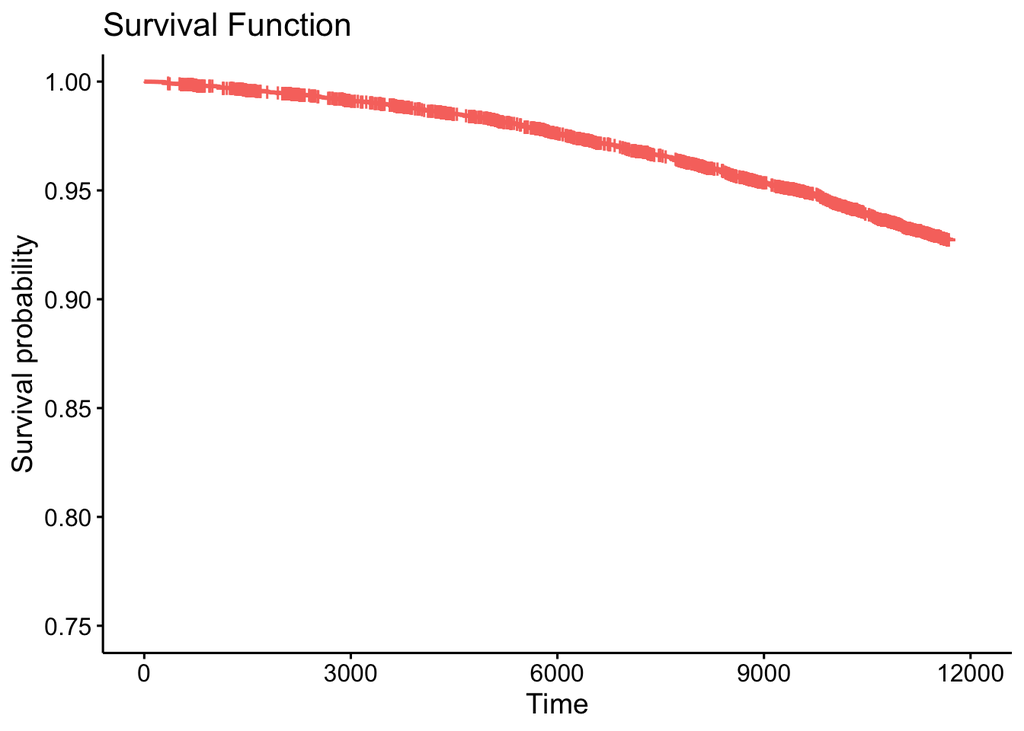

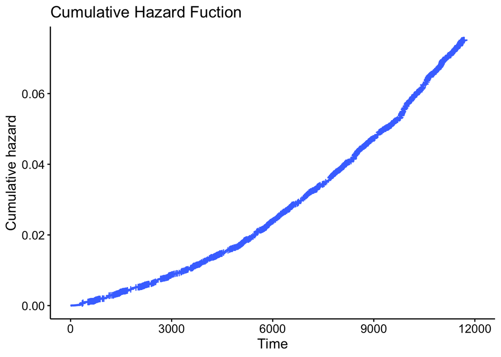

```r
g1<-ggsurvplot(survfit(cox.step1), data=dat_FIN, conf.int = FALSE, legend="none", title="Survival Function",ylim=c(0.75,1))
g2<-ggsurvplot(survfit(cox.step1), fun="cumhaz", data=dat_FIN, conf.int = FALSE, palette = "royalblue1", legend="none",title="Cumulative Hazard Fuction")
g1;g2
```

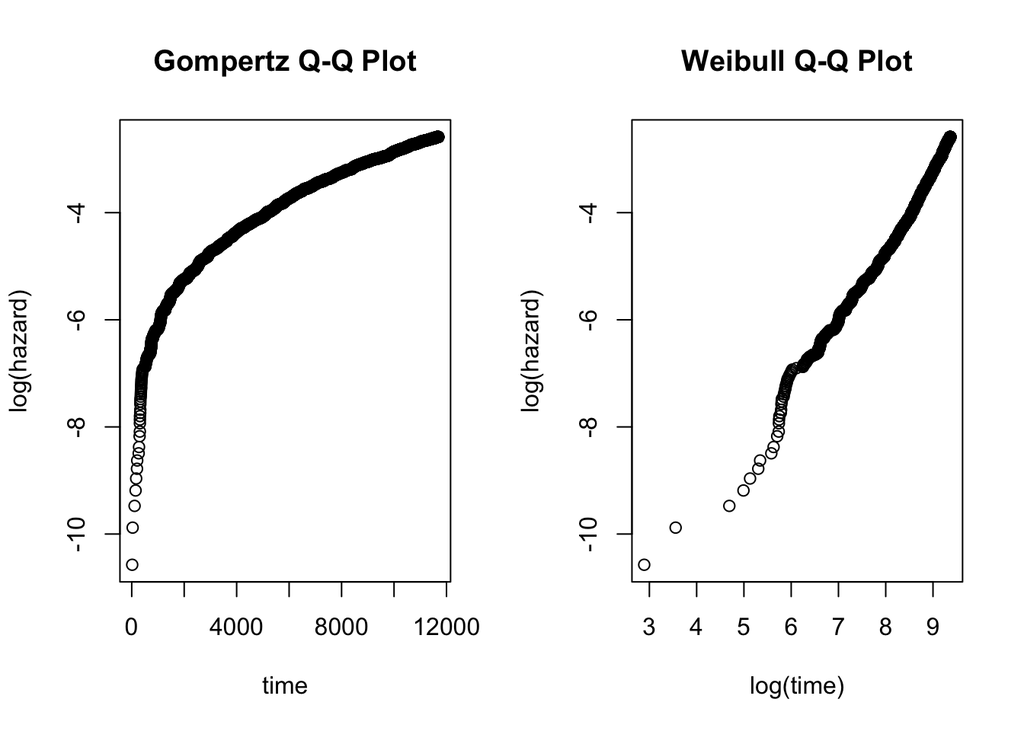

```r
S <- basehaz(cox.step1); par(mfrow=c(1,2))
with(S, plot(time, log(hazard), main="Gompertz Q-Q Plot"))
with(S, plot(log(time), log(hazard), main="Weibull Q-Q Plot"))
```

**1-c) 심장병 발생에 대한 주요변수들의 효과**

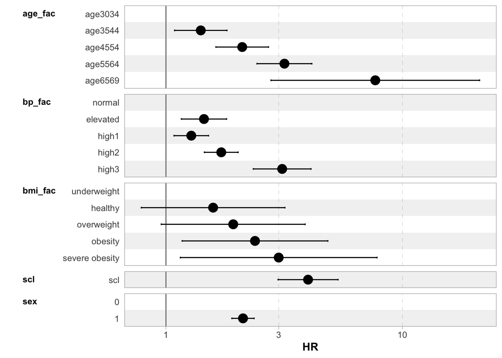

```r
cox.step1 %>% tbl_regression(exponentiate=T) %>% plot()
```

```r
#autoplot(aareg(cox.step1$formula, dat_FIN), ncol=4, scales="free")
```

**3-a) 주어진 공변량에 대해 10년 내에 심장병 걸릴 확률 + 산점도**

```r
summary(survfit(cox.step1), time=3650)
```

```
## Call: survfit(formula = cox.step1)
##
##  time n.risk n.event survival std.err lower 95% CI upper 95% CI
##  3650   3893     379    0.989 0.00417        0.981        0.997
```

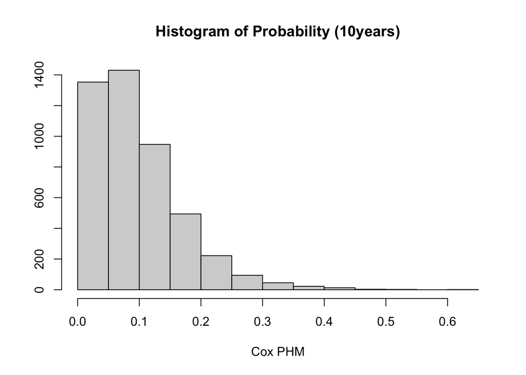

```r
lm <- lm(log(hazard)~log(time), data = S)
alpha <- summary(lm)$coefficients[1]
beta <- summary(lm)$coefficients[2]

mu.cox <- predict(cox.step1, dat_FIN, type = 'risk')
p.cox <- 1-exp(-exp((alpha+beta*(log(3650))))*mu.cox)
cox_hist <- hist(p.cox, breaks = 20, xlab="Cox PHM", main="Histogram of Probability (10years)",ylab = "")
```

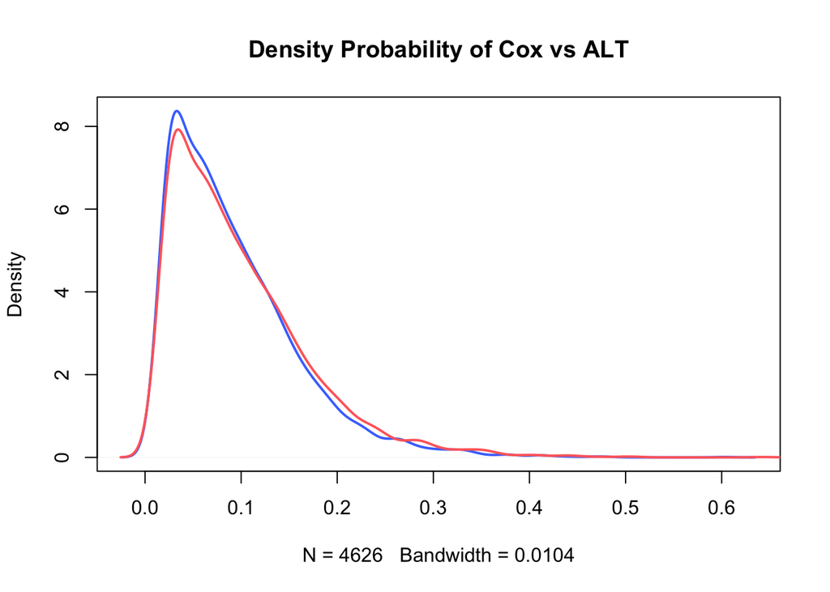

```r
#plot(p.cox, prob_alt, main='Probability of Cox vs ALT', xlab='COX', ylab='ALT')
plot(density(prob_alt), col='royalblue1', lwd=2, main='Density Probability of Cox vs ALT')
lines(density(p.cox, na.rm=T), col="indianred1",lwd=2)
```

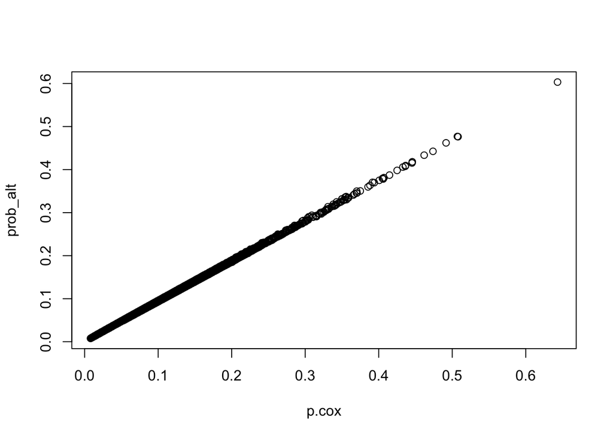

```r
plot(p.cox, prob_alt)
```

**3-c) AIC 값 제출**

```r
extractAIC(cox.step1)
```

```
## [1]    14.00 22283.22
```

**4-a) 새로운 확률변수 T (= 각 환자의 출생 시점에서 심장병 발생까지의 시간) 정의 / 그에 대한 Cox**

dat_pt4 에 $T_i^*$ 정의 / final : bp_fac + bmi_fac + scl + sex + scl:sex / AIC 21930.65

```r
dat_pt4 <- data.frame(dat_FIN, age=dat_KNN_noOUT$age)
dat_pt4 <- dat_pt4 %>% mutate(t.star=age*365.25+followup) %>% dplyr::select(-followup, -age)

#cox.pt4<-coxph(Surv(t.star, as.numeric(chdfate)-1) ~ bp_fac + bmi_fac + scl + sex, data=dat_pt4)
cox.pt4_re<-coxph(Surv(t.star, as.numeric(chdfate)-1) ~ .*., data=dat_pt4[,-1])
cox.pt4.step<-stepAIC(cox.pt4_re, direction = "both", trace = FALSE)

#extractAIC(cox.pt4)
extractAIC(cox.pt4_re)
```

```
## [1]   146.00 22054.32
```

```r
extractAIC(cox.pt4.step)
```

```
## [1]    11.00 21930.65
```

```r
cox.pt4.step
```

```
## Call:
## coxph(formula = Surv(t.star, as.numeric(chdfate) - 1) ~ bp_fac +
##     bmi_fac + scl + sex + scl:sex, data = dat_pt4[, -1])
##
##                          coef exp(coef) se(coef)      z        p
## bp_facelevated        0.33075   1.39201  0.11239  2.943  0.00325
## bp_fachigh1           0.22218   1.24880  0.08558  2.596  0.00943
## bp_fachigh2           0.42536   1.53015  0.08275  5.141 2.74e-07
## bp_fachigh3           0.75917   2.13650  0.14132  5.372 7.79e-08
## bmi_fachealthy        0.45267   1.57250  0.35677  1.269  0.20451
## bmi_facoverweight     0.62816   1.87416  0.35716  1.759  0.07862
## bmi_facobesity        0.84233   2.32178  0.36167  2.329  0.01986
## bmi_facsevere obesity 1.01530   2.76020  0.48821  2.080  0.03756
## scl                   0.70225   2.01830  0.21515  3.264  0.00110
## sex1                  0.75756   2.13307  0.05581 13.573  < 2e-16
## scl:sex1              0.83920   2.31452  0.29469  2.848  0.00440
##
## Likelihood ratio test=367.4  on 11 df, p=< 2.2e-16
## n= 4626, number of events= 1432
```

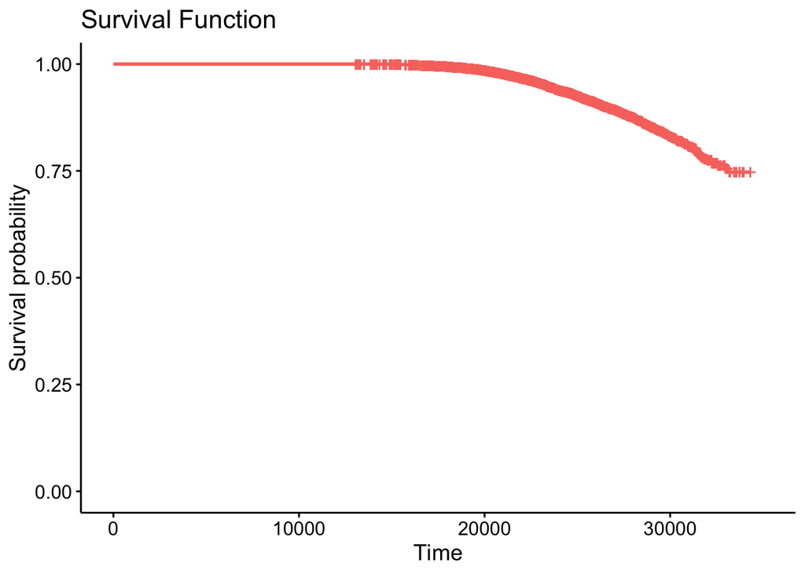

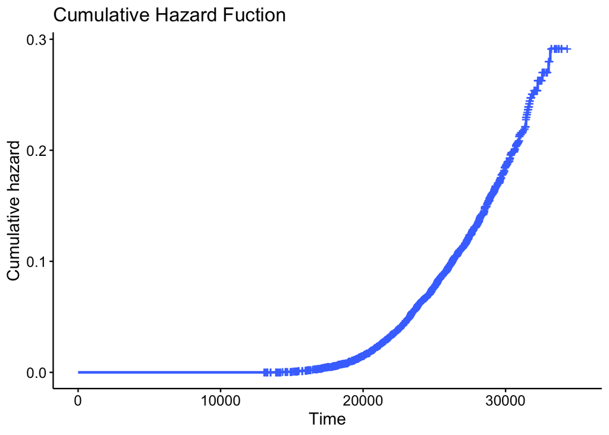

```r
g3<-ggsurvplot(survfit(cox.pt4.step), data=dat_pt4, conf.int = FALSE, legend="none", title="Survival Function")
g4<-ggsurvplot(survfit(cox.pt4.step), fun="cumhaz", data=dat_pt4, conf.int = FALSE, palette = "royalblue1", legend="none",title="Cumulative Hazard Fuction")
g3;g4
```

**4-b) T를 활용해서 10년 내 심장병 발생확률 다시 계산**

```r
par(mfrow=c(1,1))
```

```r
summary(survfit(cox.pt4.step), time=3650)
```

```
## Call: survfit(formula = cox.pt4.step)
##
##  time n.risk n.event survival std.err lower 95% CI upper 95% CI
##  3650   4626       0        1       0            1            1
```

```r
S2 <- basehaz(cox.pt4.step); par(mfrow=c(1,2))
```

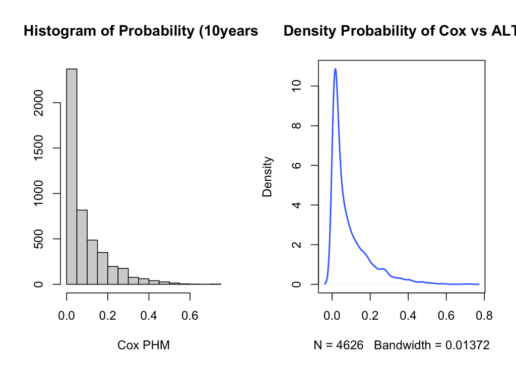

```r
lm2 <- lm(log(hazard)~log(time), data = S2[-(1:7),])
alpha2 <- summary(lm2)$coefficients[1]
beta2 <- summary(lm2)$coefficients[2]

mu.cox2 <- predict(cox.pt4.step, dat_pt4, type = 'risk')
t2 <- dat_KNN_noOUT$age*365.25 + 3650
p.cox2 <- 1-exp(-exp((alpha2+beta2*(log(t2))))*mu.cox2)
cox_hist2 <- hist(p.cox2, breaks = 20, xlab="Cox PHM", main="Histogram of Probability (10years)",ylab = "")

#plot(p.cox, prob_alt, main='Probability of Cox vs ALT', xlab='COX', ylab='ALT')
plot(density(p.cox2, na.rm = T), col='royalblue1', lwd=2, main='Density Probability of Cox vs ALT')
```